# R Notebook

## Metadata

Required libraries and runtime environment description.

```r
library(emidata)
library(tidyverse)
library(tidytext)
library(kableExtra)
library(stringr)
library(wordcloud)
library(skimr)
```

This document is an EDA notebook to explore descriptive and informative figures of the dataset *ipapers2018* in the *emidata* package. Type `?ipapers2018` for information.

## Data

The data for the analysis is in the *ipapers2018* dataset that has `136` references.

```
## Observations: 136
## Variables: 9
## $ filename <chr> "004 - A Digital Tool to Promote Alcohol.pdf", "007 -...
## $ id       <chr> "004", "007", "008", "010", "012", "013", "014", "015...
## $ type     <chr> "Article", "Article", "Article", "Article", "Article"...
## $ title    <chr> "A Digital Tool to Promote Alcohol and Drug Use Scree...
## $ abstract <chr> "Background: Translation of knowledge and skills from...
## $ journal  <chr> "JMIR RESEARCH PROTOCOLS", "Journal of medical Intern...
## $ author   <chr> "Derek D. Satre and Khanh Ly and Maria Wamsley and Al...
## $ year     <int> 2017, 2016, 2016, 2018, 2017, 2015, 2016, 2017, 2018,...
## $ keywords <chr> "depression, anxiety, alcohol, drug, training, mobile...
```

|  | variable | type | stat | level | value | formatted |
| --- | --- | --- | --- | --- | --- | --- |
| 1 | filename | character | missing | .all | 0.000000 | 0 |
| 2 | filename | character | complete | .all | 136.000000 | 136 |
| 3 | filename | character | n | .all | 136.000000 | 136 |
| 4 | filename | character | min | .all | 23.000000 | 23 |
| 5 | filename | character | max | .all | 87.000000 | 87 |
| 6 | filename | character | empty | .all | 0.000000 | 0 |
| 7 | filename | character | n_unique | .all | 136.000000 | 136 |
| 8 | id | character | missing | .all | 0.000000 | 0 |
| 9 | id | character | complete | .all | 136.000000 | 136 |
| 10 | id | character | n | .all | 136.000000 | 136 |

[output cut: 57 more lines]

As part of the text analysis of papers, including wordcloud and terms frequency analysis, read the full list of abstracts from the `papers` and process them to create a [tidy](https://www.jstatsoft.org/article/view/v059i10) data structure without [stop words](https://en.wikipedia.org/wiki/Stop_words). Reference book to text mining in tidy format: [Text Mining with R](https://www.tidytextmining.com/)

About 52 % (19009) of the total words (36218) are considered stop words.

*How many non-stop words does each abstract have?*

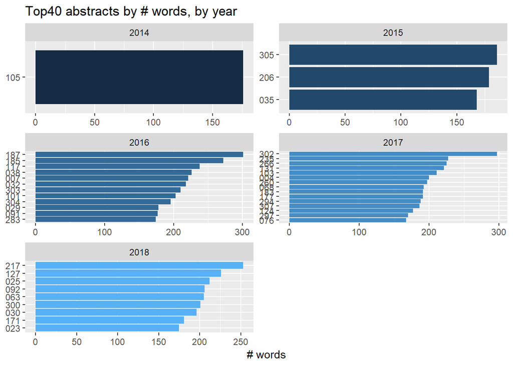

| id | filename | num_words | year |
| --- | --- | --- | --- |
| 187 | 187 - MoodHacker Mobile Web App.pdf | 301 | 2016 |
| 302 | 302 - Using a Mobile Application in the.pdf | 297 | 2017 |
| 185 | 185 - Mobile-Application based Cognitive.pdf | 272 | 2016 |
| 217 | 217 - Predictors of Utilization of a Novel.pdf | 253 | 2018 |
| 117 | 117 - Feasibility of PRIME.pdf | 238 | 2016 |
| 235 | 235 - Reducing depressive symptomatology.pdf | 227 | 2017 |
| 038 | 038 - An Ecological Momentary Intervention for Smoking.pdf | 226 | 2016 |
| 127 | 127 - Implementing a Mobile Health System.pdf | 226 | 2018 |
| 266 | 266 - Smartphone-Supported versus Full.PDF | 225 | 2017 |
| 007 | 007 - A Guided Online and Mobile Self-Help.pdf | 221 | 2016 |
| 131 | 131 - IntelliCare An Eclectic.pdf | 221 | 2017 |
| 032 | 032 - Acceptance and Commitment Therapy.pdf | 218 | 2016 |
| 025 | 025 - A study protocol for a non-randomised.pdf | 212 | 2018 |
| 103 | 103 - Effects of digital Cognitive Behavioural.pdf | 211 | 2017 |
| 303 | 303 - Using a smartphone app to reduce.pdf | 210 | 2016 |
| 092 | 092 - Development of a Smartphone Application for Eating.pdf | 206 | 2018 |
| 063 | 063 - Cognitive and Behavioral Skills Exercises.pdf | 205 | 2018 |
| 101 | 101 - Effectiveness of blended depression treatment.pdf | 203 | 2016 |
| 300 | 300 - User-Centered Design of Learn to Quit.pdf | 201 | 2018 |
| 004 | 004 - A Digital Tool to Promote Alcohol.pdf | 200 | 2017 |

## Search terms in the abstract

### Psychological terms

The detection matches full words using regex option `\b`.

- mental (and also e-mental)
- psycholog (`psycholog.*`, i.e. psychology, psychological)
- psychiatric
- emotional
- health (and also e-health, u-health)
- treatment(s) (and also pretreatment, post-treatment)
- disorder(s)
- intervention(s)
- therapy(ies)
- distress,
- affection
- depressi (`depressi.*`, i.e. depression, depressive)
- anxiety,
- ecological momentary intervention

*How often do psychological related search terms appear in each abstract?*

| id | mental | psycholog.. | psychiatric | emotional | health | treatment(s) | disorder(s) | intervention(s) | therapy/ies | distress | affection | depressi.. | anxiety | psy_all |
| --- | --- | --- | --- | --- | --- | --- | --- | --- | --- | --- | --- | --- | --- | --- |
| 101 | 5 | 0 | 0 | 0 | 3 | 12 | 1 | 0 | 1 | 0 | 0 | 1 | 0 | 23 |
| 119 | 4 | 0 | 6 | 0 | 3 | 0 | 3 | 5 | 0 | 0 | 0 | 1 | 0 | 22 |
| 302 | 0 | 0 | 0 | 0 | 0 | 18 | 1 | 0 | 2 | 0 | 0 | 1 | 0 | 22 |
| 051 | 0 | 0 | 0 | 0 | 1 | 17 | 1 | 1 | 0 | 0 | 0 | 1 | 0 | 21 |
| 068 | 2 | 1 | 0 | 0 | 2 | 5 | 0 | 2 | 3 | 1 | 0 | 1 | 3 | 20 |
| 285 | 2 | 1 | 0 | 0 | 2 | 7 | 0 | 0 | 3 | 0 | 0 | 0 | 3 | 18 |
| 029 | 7 | 1 | 0 | 0 | 6 | 2 | 0 | 0 | 0 | 1 | 0 | 0 | 0 | 17 |
| 131 | 1 | 0 | 0 | 0 | 4 | 4 | 1 | 0 | 0 | 0 | 0 | 1 | 6 | 17 |
| 160 | 5 | 0 | 0 | 0 | 8 | 1 | 1 | 0 | 0 | 2 | 0 | 0 | 0 | 17 |
| 235 | 2 | 0 | 0 | 1 | 4 | 1 | 0 | 6 | 2 | 0 | 0 | 1 | 0 | 17 |
| 025 | 0 | 0 | 0 | 0 | 1 | 1 | 2 | 1 | 1 | 0 | 0 | 0 | 10 | 16 |
| 126 | 1 | 1 | 0 | 0 | 3 | 1 | 0 | 5 | 0 | 0 | 0 | 1 | 4 | 16 |
| 217 | 6 | 1 | 0 | 0 | 4 | 2 | 1 | 0 | 0 | 0 | 0 | 1 | 1 | 16 |
| 263 | 0 | 0 | 0 | 0 | 0 | 15 | 0 | 0 | 0 | 0 | 0 | 1 | 0 | 16 |
| 305 | 2 | 1 | 0 | 0 | 2 | 5 | 0 | 4 | 2 | 0 | 0 | 0 | 0 | 16 |
| 123 | 0 | 1 | 0 | 0 | 0 | 3 | 3 | 0 | 1 | 1 | 0 | 1 | 5 | 15 |
| 185 | 3 | 0 | 0 | 0 | 4 | 1 | 1 | 4 | 1 | 0 | 0 | 1 | 0 | 15 |
| 283 | 3 | 0 | 0 | 0 | 6 | 4 | 0 | 1 | 0 | 0 | 0 | 1 | 0 | 15 |
| 304 | 2 | 0 | 1 | 0 | 3 | 4 | 2 | 3 | 0 | 0 | 0 | 0 | 0 | 15 |
| Total | 115 | 29 | 29 | 8 | 171 | 285 | 76 | 159 | 88 | 20 | 0 | 58 | 113 | 1151 |

### Technical terms

The detection matches full words using regex option `\b`.

- cell (and cell-phone, cellphone)
- mobile
- smart (and smartphone)
- portable
- phone(s)
- device(s)
- app(s)
- applicat (`applicat.*`, i.e. application)
- emotional
- mhealth
- uhealth
- ehealth
- emental
- android
- iphone

*How often do Computer science related search terms appear in each abstract?*

| id | cell | mobile | smart | portable | phone(s) | device(s) | app(s) | applicat.. | mhealth | uhealth | ehealth | emental | android | iphone | cs_all |
| --- | --- | --- | --- | --- | --- | --- | --- | --- | --- | --- | --- | --- | --- | --- | --- |
| 183 | 0 | 0 | 0 | 0 | 3 | 0 | 11 | 0 | 0 | 0 | 0 | 0 | 0 | 0 | 14 |
| 038 | 0 | 0 | 4 | 0 | 0 | 0 | 8 | 0 | 0 | 0 | 0 | 0 | 0 | 0 | 12 |
| 300 | 0 | 0 | 0 | 0 | 0 | 0 | 8 | 1 | 2 | 0 | 0 | 0 | 0 | 0 | 11 |
| 004 | 0 | 0 | 0 | 0 | 0 | 0 | 9 | 1 | 0 | 0 | 0 | 0 | 0 | 0 | 10 |
| 049 | 0 | 0 | 0 | 0 | 1 | 0 | 7 | 1 | 0 | 0 | 0 | 0 | 1 | 0 | 10 |
| 139 | 0 | 0 | 0 | 0 | 0 | 0 | 7 | 0 | 0 | 0 | 0 | 0 | 3 | 0 | 10 |
| 181 | 0 | 0 | 0 | 0 | 1 | 0 | 9 | 0 | 0 | 0 | 0 | 0 | 0 | 0 | 10 |
| 206 | 0 | 0 | 0 | 0 | 1 | 0 | 8 | 1 | 0 | 0 | 0 | 0 | 0 | 0 | 10 |
| 235 | 0 | 0 | 0 | 0 | 1 | 0 | 9 | 0 | 0 | 0 | 0 | 0 | 0 | 0 | 10 |
| 127 | 0 | 0 | 0 | 0 | 0 | 0 | 0 | 0 | 8 | 0 | 1 | 0 | 0 | 0 | 9 |
| 087 | 0 | 0 | 0 | 0 | 0 | 1 | 0 | 0 | 7 | 0 | 0 | 0 | 0 | 0 | 8 |
| 160 | 0 | 0 | 0 | 0 | 0 | 0 | 7 | 0 | 1 | 0 | 0 | 0 | 0 | 0 | 8 |
| 266 | 0 | 0 | 0 | 0 | 0 | 0 | 8 | 0 | 0 | 0 | 0 | 0 | 0 | 0 | 8 |
| 269 | 0 | 0 | 0 | 0 | 1 | 0 | 0 | 0 | 7 | 0 | 0 | 0 | 0 | 0 | 8 |
| 021 | 0 | 0 | 0 | 0 | 0 | 0 | 7 | 0 | 0 | 0 | 0 | 0 | 0 | 0 | 7 |
| 071 | 0 | 0 | 3 | 0 | 2 | 1 | 0 | 1 | 0 | 0 | 0 | 0 | 0 | 0 | 7 |
| 090 | 0 | 0 | 0 | 0 | 1 | 0 | 5 | 1 | 0 | 0 | 0 | 0 | 0 | 0 | 7 |
| 115 | 0 | 0 | 0 | 0 | 0 | 0 | 6 | 1 | 0 | 0 | 0 | 0 | 0 | 0 | 7 |
| 192 | 0 | 0 | 0 | 0 | 0 | 0 | 6 | 1 | 0 | 0 | 0 | 0 | 0 | 0 | 7 |
| 303 | 0 | 0 | 0 | 0 | 0 | 0 | 7 | 0 | 0 | 0 | 0 | 0 | 0 | 0 | 7 |
| Total | 0 | 0 | 8 | 0 | 37 | 11 | 291 | 65 | 35 | 0 | 2 | 0 | 6 | 0 | 455 |

### Combined psycological and technical terms

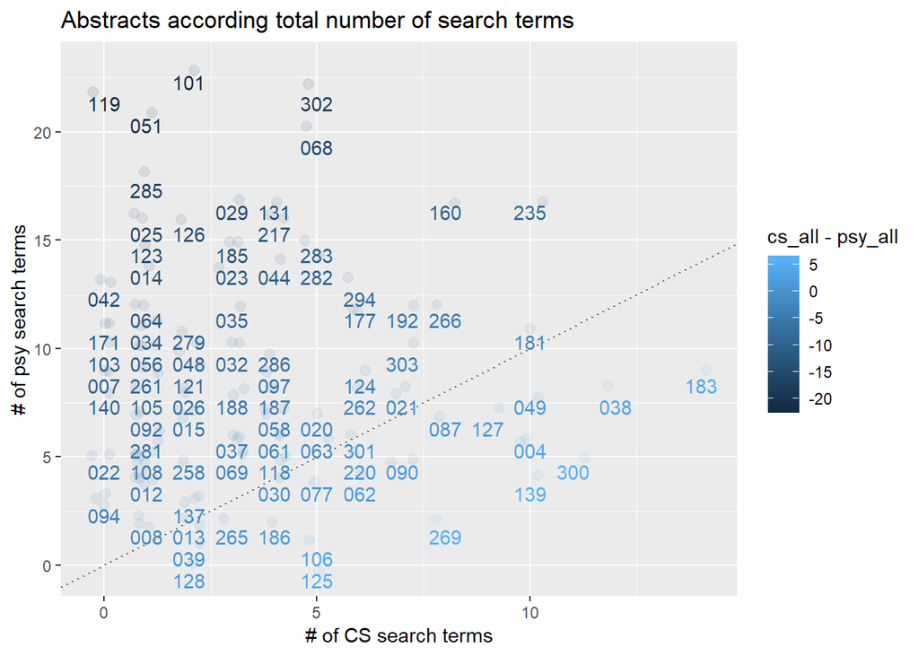

Paper 101 (dark blue) ranks first with 23 appearances of search terms related to psychology in the abstract. On the other end, paper 183 (light blue) ranks first with 14 appearances of search terms related to computer science in the abstract. Looking at the plot, papers with psychology terms outnumber papers with computer scince terms. Dark blue numbers dominate

## Frequency analysis of top words (most frequent) in the abstracts

*Word cloud of 25 top words in abstracts*

[figure not shown]

| place | word | n | # abstracts |
| --- | --- | --- | --- |
| 1 | app | 285 | 76 |
| 2 | treatment | 255 | 85 |
| 3 | participants | 206 | 77 |
| 4 | study | 185 | 94 |
| 5 | mobile | 182 | 79 |
| 6 | health | 171 | 79 |
| 7 | depression | 167 | 57 |
| 8 | intervention | 159 | 63 |
| 9 | smartphone | 158 | 69 |
| 10 | symptoms | 131 | 59 |
| 11 | mental | 115 | 59 |
| 12 | anxiety | 113 | 40 |
| 13 | application | 107 | 52 |
| 14 | trial | 105 | 59 |
| 15 | cbt | 103 | 26 |
| 16 | patients | 99 | 44 |
| 17 | cognitive | 86 | 46 |
| 18 | therapy | 86 | 59 |
| 19 | apps | 82 | 40 |
| 20 | weeks | 79 | 37 |
| 21 | time | 77 | 44 |
| 22 | disorder | 76 | 58 |
| 23 | interventions | 76 | 49 |
| 24 | research | 76 | 45 |
| 25 | clinical | 72 | 49 |

```r
#TODO: How do top words and search terms correlate?
# Do it manually or automated. Which of the top words are also search terms? Are search terms in the top of the list? Are there standing top words that were nt search terms?
#TODO: Visualise table of occurrances of top words
#TODO: How do the top words correlated with the top keywords in the corpus?
#TODO: How do the top words correlated with the top keywords in each abstract?
```